# The F-Distribution & One-Way ANOVA

A Concise Guide to Variance Ratios, ANOVA, and Post-Hoc Comparisons

2026-10-08

## 1. Executive Summary & Core Concept

- **Statistical Foundation**: Developed by Sir Ronald A. Fisher in the 1920s.
- **Core Function**: Measures the ratio of two independent sample variances.
- **Primary Purpose**: Evaluates variability across multiple groups simultaneously.
- **Key Metric**: The **Variance Ratio** ($F = \text{Between-Group Variance} / \text{Within-Group Variance}$).
- **Main Advantage**: Controls family-wise Type I error rates across $k$ groups.

## 2. Mathematical Definition & Key Properties

- **Ratio of Chi-Squares**: Ratio of two independent chi-square variables divided by their degrees of freedom.
- **Parameter Pair**: Governed by numerator $df_1 = n_1 - 1$ and denominator $df_2 = n_2 - 1$.
- **Non-Negative Support**: Always $F \ge 0$ since variances are non-negative.
- **Asymmetric Shape**: Positively skewed with a long right tail.
- **Reciprocal Property**: Lower percentiles satisfy $F_{\alpha, df_1, df_2} = 1 / F_{1-\alpha, df_2, df_1}$.
- **Special Equivalence**: For $k = 2$ groups, the $F$-statistic equals Student’s $t^2$ ($F = t^2$).

## 3. Behavior & Interpretation

- **Null Scenario ($F \approx 1$)**:
  - Between-group variation matches background noise.
  - Group mean differences are likely due to random chance.
- **Alternative Scenario ($F \gg 1$)**:
  - Between-group variation significantly exceeds random variation.
  - Signals genuine treatment or group differences.
- **Underlying Assumptions**:
  - Normally distributed populations.
  - Homogeneity of variance (equal group variances).
  - Independent sampling of observations.

## 4. Scope of Applications

- **Variance Ratio Test**: Compares two population variances ($H_0: \sigma_1^2 = \sigma_2^2$).
- **One-Way ANOVA**: Tests equality of $k$ group means ($H_0: \mu_1 = \mu_2 = \dots = \mu_k$).
- **Advanced Designs**: Applies to Randomized Complete Block, Factorial, and Repeated Measures ANOVA.
- **Multivariable Regression**: Tests overall model significance ($F = MSR / MSE$) and extra sums of squares.

## 5. One-Way ANOVA Hypothesis Testing Example

### Study Design & Raw Data

- **Context**: Testing 3 weight-loss diets ($k = 3$) across $N = 9$ subjects ($n_j = 3$ per diet) .
- **Diet 1 ($Group_1$)**: 4, 5, 6 pounds lost.
- **Diet 2 ($Group_2$)**: 7, 8, 9 pounds lost.
- **Diet 3 ($Group_3$)**: 10, 11, 12 pounds lost.

### Step-by-Step Calculation Summary

- **Group Means**: $\bar{x}_1 = 5$, $\bar{x}_2 = 8$, $\bar{x}_3 = 11$.
- **Grand Mean**: $\bar{x}_{..} = (5 + 8 + 11) / 3 = 8$.
- **Sum of Squares Among ($SSA$)**: $3(5-8)^2 + 3(8-8)^2 + 3(11-8)^2 = 54$.
- **Among Degrees of Freedom ($df_A$)**: $k - 1 = 3 - 1 = 2$.
- **Mean Square Among ($MSA$)**: $SSA / df_A = 54 / 2 = 27$.
- **Sum of Squares Within ($SSW$)**: $(1+0+1) + (1+0+1) + (1+0+1) = 6$.
- **Within Degrees of Freedom ($df_W$)**: $N - k = 9 - 3 = 6$.
- **Mean Square Within ($MSW$)**: $SSW / df_W = 6 / 6 = 1$.
- **Calculated $F$-Statistic**: $F = MSA / MSW = 27 / 1 = 27$.

### ANOVA Summary Table

| Source of Variation | Sum of Squares ($SS$) | Degrees of Freedom ($df$) | Mean Square ($MS$) | $F$-Value |
| --- | --- | --- | --- | --- |
| **Among Groups** | 54 | 2 | $MSA = 27$ | **$F = 27.0$** |
| **Within Groups** | 6 | 6 | $MSW = 1$ | — |
| **Total** | 60 | 8 | — | — |

- **Decision**: Computed $F = 27$ far exceeds the critical value $F_{0.05, 2, 6} = 5.14$ ($P < 0.001$), confirming statistically significant differences among the three diets.

## 6. Post-Hoc Pairwise Comparisons (Tukey HSD & Bonferroni)

- **Why Post-Hoc Testing Is Essential**:
  - An overall $F$-test indicates *that* group means differ, but not *which* specific pairs differ.
  - Running multiple unadjusted $t$-tests inflates the overall Type I error rate.
  - Post-hoc tests pinpoint specific pairwise differences while maintaining error control.
- **Tukey’s Honestly Significant Difference (HSD)**:
  - **Method**: Uses the Studentized Range distribution to calculate a single critical threshold for all pairwise differences.
  - **Best Used For**: All possible pairwise comparisons among group means.
  - **Key Feature**: Maintains exact family-wise error rate $\alpha$ without being overly conservative.
  - **In R**: Evaluated via `TukeyHSD(anova_model)`.
- **Bonferroni Adjustment**:
  - **Method**: Adjusts significance threshold to $\alpha / m$ (or multiplies $p$-values by $m$, where $m = k(k-1)/2$ comparisons).
  - **Best Used For**: Small set of pre-planned or custom pairwise comparisons.
  - **Key Feature**: Highly robust and versatile, but can become overly conservative as $k$ grows.
  - **In R**: Evaluated via `pairwise.t.test(..., p.adjust.method = "bonferroni")`.

## 7. Complete R Code Implementation

```r
# --- 1. Load Study Data ---
diet_data <- data.frame(
  Diet = factor(rep(c("Diet 1", "Diet 2", "Diet 3"), each = 3)),
  WeightLoss = c(4, 5, 6, 7, 8, 9, 10, 11, 12)
)

# --- 2. Fit One-Way ANOVA Model ---
anova_model <- aov(WeightLoss ~ Diet, data = diet_data)

# --- 3. Display ANOVA Summary Table ---
summary(anova_model)
```

```
##             Df Sum Sq Mean Sq F value Pr(>F)
## Diet         2     54      27      27  0.001 ***
## Residuals    6      6       1
## ---
## Signif. codes:  0 '***' 0.001 '**' 0.01 '*' 0.05 '.' 0.1 ' ' 1
```

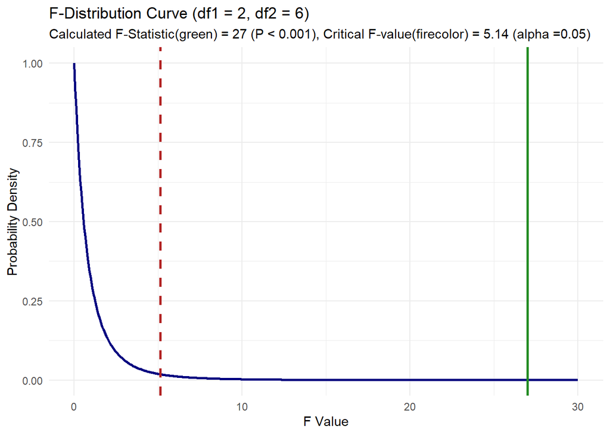

```r
# --- 4. Plot F-Distribution Curve & Test Statistic ---
f_stat <- summary(anova_model)[[1]][["F value"]][1]
df1 <- summary(anova_model)[[1]][["Df"]][1]
df2 <- summary(anova_model)[[1]][["Df"]][2]

x_vals <- seq(0, 30, length.out = 500)
y_vals <- df(x_vals, df1, df2)
plot_df <- data.frame(x = x_vals, y = y_vals)
criticalF <- qf(p = 1-0.05, df1 = 2, df2 = 6)
ggplot(plot_df, aes(x = x, y = y)) +
  geom_line(color = "navy", size = 1) +
  geom_vline(xintercept = f_stat, color = "forestgreen", linetype = "solid", size = 1) +
  geom_vline(xintercept = criticalF, color = "firebrick", linetype = "dashed", size = 1) +
  labs(
    title = "F-Distribution Curve (df1 = 2, df2 = 6)",
    subtitle = paste("Calculated F-Statistic(green) =", f_stat, "(P < 0.001),",
                     "Critical F-value(firecolor) =", round(criticalF,2), "(alpha =0.05)"),
    x = "F Value",
    y = "Probability Density"
  ) +
  theme_minimal()
```

```r
# --- 5. Post-Hoc Comparisons: Tukey HSD ---
cat("\n--- Tukey HSD Pairwise Comparisons ---\n")
```

```
##
## --- Tukey HSD Pairwise Comparisons ---
```

```r
tukey_results <- TukeyHSD(anova_model)
print(tukey_results)
```

```
##   Tukey multiple comparisons of means
##     95% family-wise confidence level
##
## Fit: aov(formula = WeightLoss ~ Diet, data = diet_data)
##
## $Diet
##               diff       lwr      upr     p adj
## Diet 2-Diet 1    3 0.4947644 5.505236 0.0242291
## Diet 3-Diet 1    6 3.4947644 8.505236 0.0007942
## Diet 3-Diet 2    3 0.4947644 5.505236 0.0242291
```

```r
# --- 6. Post-Hoc Comparisons: Bonferroni Adjustment ---
cat("\n--- Bonferroni Adjusted Pairwise t-Tests ---\n")
```

```
##
## --- Bonferroni Adjusted Pairwise t-Tests ---
```

```r
bonf_results <- pairwise.t.test(
  x = diet_data$WeightLoss,
  g = diet_data$Diet,
  p.adjust.method = "bonferroni"
)
print(bonf_results)
```

```
##
##  Pairwise comparisons using t tests with pooled SD
##
## data:  diet_data$WeightLoss and diet_data$Diet
##
##        Diet 1  Diet 2
## Diet 2 0.03121 -
## Diet 3 0.00097 0.03121
##
## P value adjustment method: bonferroni
```